# LR: Basic Statistics and Heatmap

UA Research Team

April 24, 2019

# 1 Little Rock Child Maltreatment

## 1.1 Background

This is an exploratory analysis of data-set that reports child maltreatment incidents in Little rock.

## 1.2 Map of Incidents

First we plot the incidents on a map like a point process using the latitude and longitudes extracted by `ggmap`.

```r
rm(list = ls())
require(devtools)
# devtools::install_github("dkahle/ggmap", ref = "tidyup")
# devtools::install_github("thomasp85/patchwork")
library(pacman)
p_load("sf"             # Spatial data objects and methods
       ,"mapview"        # Interactive Map Viewing
       ,"ggmap"          # ggplot2 addon for base maps
       ,"cowplot"
       ,"spatstat"       # KDE and other spatial functions
       ,"raster"         # cell-based spatial operations
       ,"tidyverse"      # data manipulation framework
       ,"Hmisc"          # using cut2(  functions for ggplot legends
       ,"fitdistrplus"   # Distribution fitting functions
       ,"lubridate"      # Power tools for handling dates
       ,"tidycensus"
       ,"lwgeom"
       ,"Hmisc"
       ,"hrbrthemes"
       ,"gridExtra"
       ,"spdep"          # KNN functions
       ,"foreach"
       ,"doParallel"
       ,"corrplot"
       ,"ranger"         # randomforest implimentation
       ,"glmnet"         # for Ridge and Lasso Regression
       ,"knitr"          # for kable table
       ,"kableExtra"
       ,"FNN"            # KNN for CPS vs. NN plots
       ,"groupdata2"
       ,"htmltools"
       ,"viridis"
       ,"viridisLite")
```

```r
# rm(list = ls())
setwd("~/Data/LR-Child")
crime <- read.csv(file="child-mt-accepted.csv", header=T,sep=",",
                  na.strings='NULL')
attach(crime)

crime$STR_NME <- crime$STR_NME %>% as.character %>% str_to_title
crime$CTY_NME <- crime$CTY_NME %>% as.character %>% str_to_title

full_add <- paste(STR_NBR,STR_NME,STR_SFX_TYP_DESC, ",",
                        CTY_NME,",", "AR")
head(full_add)
```

[1] “4511 LUDWIG , LITTLE ROCK , AR”  
[2] “800 BEACH Street , NORTH LITTLE ROCK , AR” [3] “8208 WESTWOOD Avenue , LITTLE ROCK , AR”  
[4] “6838 CANTRELL Road , LITTLE ROCK , AR”  
[5] “400 COLLEGE PARK , NORTH LITTLE ROCK , AR” [6] “17809 LAWSON Road , LITTLE ROCK , AR”

```r
library(ggmap)
register_google(key = "<your key here>")
geocoded_latlon <- geocode(crime$full_add,output="latlon")
geocoded_latlon %>% head()
crime.gc <- cbind(crime, full_add,geocoded_latlon)
write.csv(crime.gc, "LR-child-mt-accepted-geocoded.csv")
```

## 1.3 Different City Names

```r
setwd("~/Data/LR-Child")
crime.gc.read <- read.csv(file="LR-child-mt-accepted-geocoded.csv",
                     header=T, sep=",")

tab = as.data.frame(table(crime.gc.read$CTY_NME))
cat("Number of different city names", nrow(tab))
```

Number of different city names 207

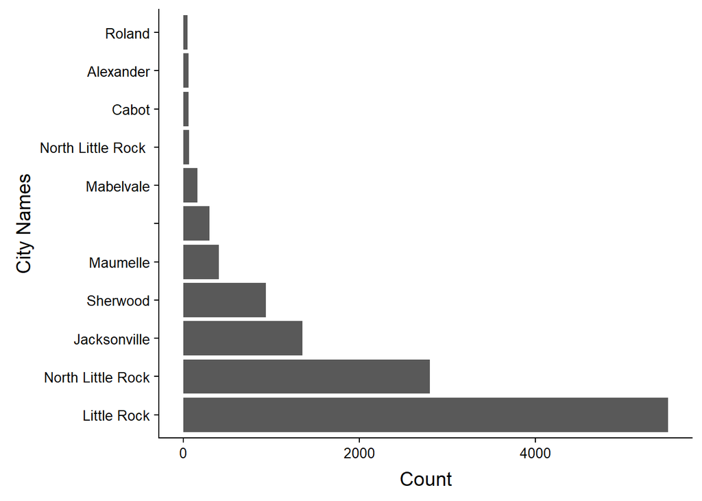

```r
tab = tab %>% filter(Freq > 50)

ggplot(tab, aes(x = reorder(Var1, -Freq), y=Freq)) + geom_bar(stat="identity") +
  xlab("City Names") + ylab("Count") + coord_flip() +
  theme(axis.text=element_text(size=10))
```

It appears there are many different city names in this data – what do they represent?

For this report, we filter the city names by “Little Rock” and use Little Rock boundaries to filter out addresses that are outside LR.

```r
crime.gc.lr = crime.gc.read %>% filter(CTY_NME == "Little Rock")%>%
  filter(lat >= 34.62606 & lat <= 34.82195) %>%
  filter(lon >= -92.52091 & lon <= -92.15494)

nrow(crime.gc.lr)
```

[1] 5136

[figure not shown]

```r
qmplot(lon, lat, data = crime.gc.lr)
```

[figure not shown]

```r
qmplot(lon, lat, data = crime.gc.lr, geom = "point", maptype = "toner-lite", darken = .5, color = I("red"), legend = "topleft") +
  stat_density_2d(aes(fill = ..level..), geom = "polygon", alpha = .5, color = NA) +
  scale_fill_gradient2("Propensity", low = "white", mid = "yellow", high = "red", midpoint = 60)
```

## 1.4 Dates of Incidents

```r
library(lubridate)
# str(crime.gc)
crime.gc.lr$Incident.Date <- ifelse(as.character(crime.gc.lr$Incident.Date) == "",as.character(crime.gc.lr$Referral.Date),as.character(crime.gc.lr$Incident.Date))

crime.gc.lr$Incident.Date <- as.Date(crime.gc.lr$Incident.Date, format = "%m/%d/%Y" )
crime.gc.lr$IncidentYear <- lubridate::year(ymd(crime.gc.lr$Incident.Date))
crime.gc.lr$IncidentWeek <- lubridate::week(ymd(crime.gc.lr$Incident.Date))


library(dplyr)

crime.yearly.ct <- crime.gc.lr %>% filter(IncidentYear>=2015) %>% group_by(IncidentYear) %>% dplyr::summarise(count = n())

crime.weekly.ct <- crime.gc.lr %>% filter(IncidentYear>=2015) %>% group_by(IncidentYear, IncidentWeek ) %>%
  dplyr::summarise(count = n())
```

### 1.4.1 Weekly Counts

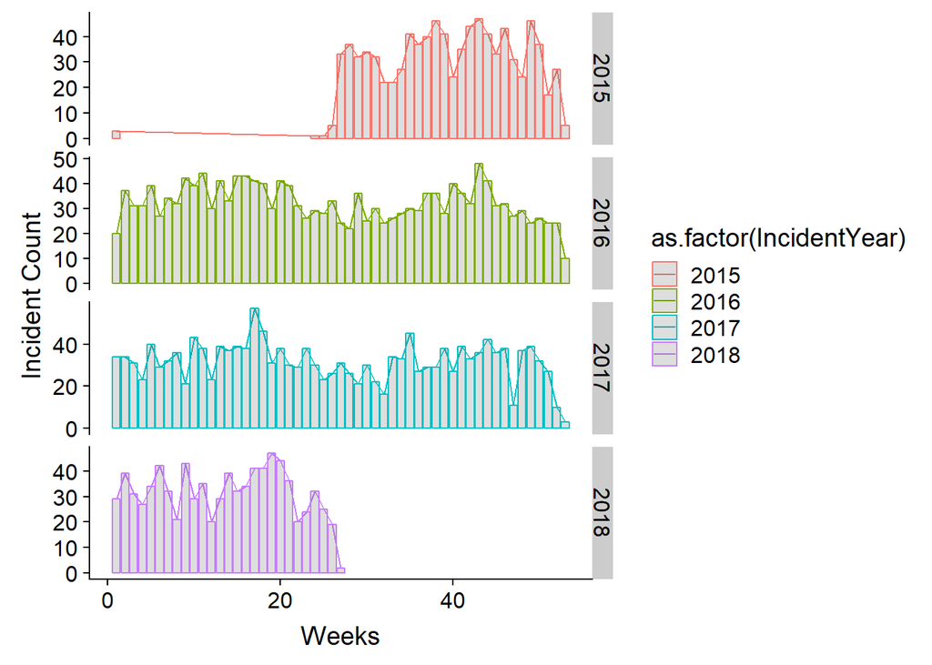

```r
library(ggplot2)
(crime.plot <- ggplot(crime.weekly.ct, aes(x = IncidentWeek, y = count, group = as.factor(IncidentYear), colour = as.factor(IncidentYear)))+
geom_line(stat = "identity")+geom_bar(alpha = 0.2,stat = "identity")+ylab("Incident Count")+
  xlab("Weeks") +
  facet_grid(IncidentYear~.,scales="free_y")+
  theme(legend.position="right"))
```

### 1.4.2 Yearly Counts

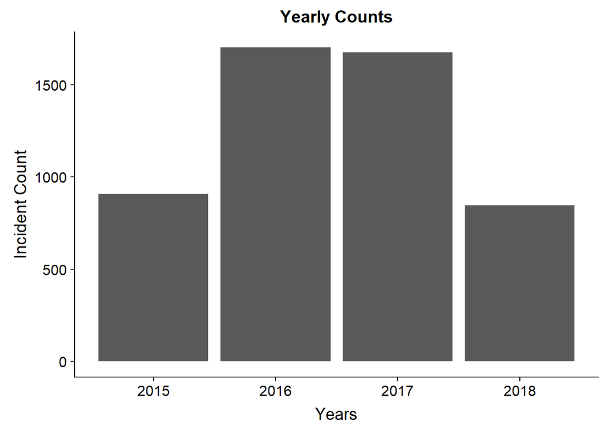

```r
(crime.plot <- ggplot(crime.yearly.ct, aes(x = IncidentYear, y = count))+
  geom_bar(stat="identity") +ylab("Incident Count")+
  xlab("Years") +labs(title = "Yearly Counts") +
  theme(panel.grid.major = element_blank(),panel.grid.minor = element_blank(), axis.line = element_line(colour = "black"))+
    theme(legend.position="right"))
```

# 2 Animated Map

This animation shows how the incidents moved over time - the animation shows the points on the map of LR over years from 2015 to 2018.

[figure not shown]

```r
library(gganimate)
crime.ct.yr <- crime.gc.lr %>% filter(IncidentYear>=2015) %>% group_by(lon, lat, IncidentYear) %>%
  dplyr::summarise(count = n())

p <- qmplot(lon, lat, data = crime.ct.yr, maptype = "toner-lite", color = I("red"))

p<- p + geom_point(aes(x = lon, y = lat, size = count),
             data = crime.ct.yr, colour = 'purple', alpha = .7) +
  labs(title = 'Year: {frame_time}', x = 'lon', y = 'lat') +
  transition_time(IncidentYear)

animate(p, fps = 1, nframes = 4)
```